# STATS769-Lab 03

Xuan Fang

8/22/2020

# Shell Command

```bash
## Change to new directory
cd ~/UNI_HOME/echome/STATS769/Lab3
```

# Task 1

By using Linux shell tools, there are $100,000$ lines in the data file.

```bash
## Use an absolute path to refer to the data file
wc -l /course/COVID/Lab03/covid-small.csv # 100,000
```

```
## 100000 /course/COVID/Lab03/covid-small.csv
```

## Description:

To print the count of the lines present in a file by passing the `-l` option to `wc`.

# Task 2

```bash
## Running R
R
```

The following code reads the CSV file into R. However, it shows $99,975$ rows.

```r
## The working directory defaults to the directory in which R started.
cases <- read.csv("/course/COVID/Lab03/covid-small.csv") # Using the absolute path
nrow(cases) # 99,975
```

```
## [1] 99975
```

```bash
## Quit the R environment
q()
```

## Commentary:

- The data come in the form of one CSV file, which contains $99,975$ individual COVID-19 cases.
- The discrepancy between the two methods comes from the lines in the data file that spread across multiple lines. There are $25$ of those lines, which can cause problems (might be identified as lines of observations) in our analysis if we do not deal with it.

# Task 3

We noticed that the Lines 5 belongs to the observation no.3 (Lines 4), but it is split across multiple lines. The `source` field contains a new line (Lines 5).

```bash
head -5 /course/COVID/Lab03/covid-small.csv
```

```
## ID,age,sex,city,province,country,latitude,longitude,geo_resolution,date_onset_symptoms,date_admission_hospital,date_confirmation,symptoms,lives_in_Wuhan,travel_history_dates,travel_history_location,reported_market_exposure,additional_information,chronic_disease_binary,chronic_disease,source,seque…
## 000-1-1,,male,Shek Lei,Hong Kong,China,22.3650193,114.133808,point,,,14.02.2020,,,22.01.2020,China,,Case 55; mainland China travel via the Lok Ma Chau border crossing,False,,https://www.scmp.com/news/hong-kong/health-environment/article/3050681/coronavirus-hong-kong-confirms-three-news-cases,,"cr…
## 000-1-10,78,male,Vo Euganeo,Veneto,Italy,45.2977477,11.6583815,point,,,21.02.2020,,,,,,Hospitalized on 12.02.2020 for other reasons,False,,https://www.corriere.it/cronache/20_febbraio_21/coronavirus-italia-cosa-sappiamo-casi-codogno-lombardia-27fa736c-548b-11ea-9196-da7d305401b7.shtml,,death,22.0…
## 000-1-100,61,female,,,Singapore,1.35346,103.8151,admin0,,,14.02.2020,,,,,,"Case 65; family member of Case 50, a DBS employee, as is Case 55",False,,"https://www.channelnewsasia.com/news/singapore/coronavirus-covid-19-singapore-cases-grace-assembly-of-god--12434646
## https://bnonews.com/wp-content/uploads/2020/02/2172020Cases.pdf",,discharge,17.02.2020,,,,,,Singapore,201.0,,
```

## Description:

To show the first five lines by passing the `-5` option to `head`.

# Task 4

We cannot use this to detect the offending lines because there are commas within some fields.

```bash
awk -F, -e '{if (NR <= 5) print(NF)}' /course/COVID/Lab03/covid-small.csv #33, 34, 33, 23, 13
```

```
## 33
## 34
## 33
## 23
## 13
```

## Description:

- To use comma for the input field separator by passing the `-F,` option to `awk`;
- Using `NF` command (which keeps a count of the number of fields within the current input record) combine with `print` command to print the number of fields for each of the first five lines (setting `NR` less than or equal to 5).

# Task 5

We can find the problem lines in the data file by finding the lines with an even number of fields (an odd number of double-quotes). For example, in the first five lines, Lines 4 and 5 are problematic (having 4 and 2 fields, respectively).

```bash
awk -F'"' -e '{if (NR <= 5) print(NF)}' /course/COVID/Lab03/covid-small.csv #1, 3, 1, 4, 2
```

```
## 1
## 3
## 1
## 4
## 2
```

## Description:

- To use double-quote for the input field separator by passing the `-F'"'` option to `awk`;
- Use single quotes (’) to escape everything;
- Using `NF` command (which keeps a count of the number of fields within the current input record) combine with `print` command to print the number of fields for each of the first five lines (setting `NR` less than or equal to 5).

# Task 6

Use `awk` to print the first six lines that have an even number of fields, using a double-quote as the field separator.

```bash
awk -F'"' -e 'NF % 2 == 0{print; count++; if(count==6) exit}' /course/COVID/Lab03/covid-small.csv
```

```
## 000-1-100,61,female,,,Singapore,1.35346,103.8151,admin0,,,14.02.2020,,,,,,"Case 65; family member of Case 50, a DBS employee, as is Case 55",False,,"https://www.channelnewsasia.com/news/singapore/coronavirus-covid-19-singapore-cases-grace-assembly-of-god--12434646
## https://bnonews.com/wp-content/uploads/2020/02/2172020Cases.pdf",,discharge,17.02.2020,,,,,,Singapore,201.0,,
## 000-1-105,25,male,Fernvale Road,,Singapore,1.393697,103.87613499999999,point,01.02.2020,,15.02.2020,,,,,,Case 71;Singapore Citizen with no recent travel history to China. He is a contact of Case 66 and 70,False,,"https://www.moh.gov.sg/news-highlights/details/one-more-case-discharged-five-new-cas…
## https://bnonews.com/wp-content/uploads/2020/02/2162020Cases.pdf",,discharge,05.03.2020,,Fernvale Road,,,,Singapore,3293.0,,
## 000-1-106,40,male,Woodlands Crescent,,Singapore,1.4466,103.801742,point,10.02.2020,14.02.2020,15.02.2020,,,,,,"Case 72; Chinese national who is a Singapore Work Pass holder, and has no recent travel history to China. He is a non-medical contact of Case 59 and linked with case 79",False,,"https://…
## https://bnonews.com/wp-content/uploads/2020/02/2162020Cases.pdf (c) https://www.moh.gov.sg/news-highlights/details/four-more-cases-discharged-three-new-cases-of-covid-19-infection-confirmed",,discharge,27.02.2020,,Woodlands Crescent,,,,Singapore,9349.0,,
```

## Description:

- Use `NF % 2 == 0` representing the condition of even number of fields;
- When the number of the even number of fields hit six, then exit the `print` execution.

# Task 7

Use `awk` to print the first six lines that have an odds number of fields, using a double-quote as the field separator.

```bash
awk -F'"' -e 'NF % 2 == 1{print; count++; if(count==6) exit}' /course/COVID/Lab03/covid-small.csv
```

```
## ID,age,sex,city,province,country,latitude,longitude,geo_resolution,date_onset_symptoms,date_admission_hospital,date_confirmation,symptoms,lives_in_Wuhan,travel_history_dates,travel_history_location,reported_market_exposure,additional_information,chronic_disease_binary,chronic_disease,source,seque…
## 000-1-1,,male,Shek Lei,Hong Kong,China,22.3650193,114.133808,point,,,14.02.2020,,,22.01.2020,China,,Case 55; mainland China travel via the Lok Ma Chau border crossing,False,,https://www.scmp.com/news/hong-kong/health-environment/article/3050681/coronavirus-hong-kong-confirms-three-news-cases,,"cr…
## 000-1-10,78,male,Vo Euganeo,Veneto,Italy,45.2977477,11.6583815,point,,,21.02.2020,,,,,,Hospitalized on 12.02.2020 for other reasons,False,,https://www.corriere.it/cronache/20_febbraio_21/coronavirus-italia-cosa-sappiamo-casi-codogno-lombardia-27fa736c-548b-11ea-9196-da7d305401b7.shtml,,death,22.0…
## 000-1-1000,,,Zhengzhou City,Henan,China,34.62931,113.46799999999999,admin2,,,26.01.2020,,,,,,,False,,https://news.163.com/special/epidemic/?spssid=7283291fcdba1d8c2d13ee3da2cfb760&spsw=7&spss=other,,,,,,,Zhengzhou City,Henan,China,10115.0,,
## 000-1-10000,,,Pingxiang City,Jiangxi,China,27.51356,113.9029,admin2,,,14.02.2020,,,,,,,False,,http://hc.jiangxi.gov.cn/doc/2020/02/15/138898.shtml,,,,,,,Pingxiang City,Jiangxi,China,7079.0,,
## 000-1-10001,,,Yichun City,Jiangxi,China,28.30755,114.9732,admin2,,,14.02.2020,,,,,,,False,,http://hc.jiangxi.gov.cn/doc/2020/02/15/138898.shtml,,,,,,,Yichun City,Jiangxi,China,9818.0,,
```

## Description:

- Use `NF % 2 == 1` representing the condition of odds number of fields;
- When the number of the even number of fields hit six, then exit the `print` execution.

# Task 8

Use `grep` to search for lines that do NOT start with a digit and `wc` to count them.

```bash
grep -v '^[0-9]' /course/COVID/Lab03/covid-small.csv| wc -l # 25
```

```
## 25
```

## Commentary:

There are $25$ lines that do not start with a digit, which fully explains the discrepancy between the number of lines in the data file ($100,000$) and the number of rows in the data frame in R ($99,975$) as mentioned in Q1 & Q2.

## Description:

- To search for lines in the file by using `grep`;
- `^[0-9]` denotes the beginning of a line with digit;
- Passing `-v` option to `grep` to output all the lines that do not match the condition.

## Task 9

In R, create variables `deceased` and `years`.

Create variables `deceased`:

```r
deceased <- cases$outcome %in%
     c("dead", "Dead", "death", "Death", "Deceased", "died", "Died")
```

Among the observations, $102$ cases were deceased.

```r
table(deceased)
```

```
## deceased
## FALSE  TRUE
## 99873   102
```

The overall proportion of cases in the data set that have died is 0.001020255.

```r
mean(deceased, na.rm = TRUE)
```

```
## [1] 0.001020255
```

Create variables `years`: The `age` variable must also have some unusual (non-numeric) values in it because it is read in as a character (factor) column.

```r
class(cases$age)
```

```
## [1] "character"
```

We can see that the `age` for some patients has been recorded with a time interval, such as ‘20-29’.

```r
head(cases$age[grep("[-]", cases$age)])
```

```
## [1] "40-49" "20-29" "40-89" "40-89" "40-89" "40-89"
```

There are $1892$ cases contain time unit or time interval.

```r
sum(grepl("[a-z|-]", cases$age))
```

```
## [1] 1892
```

A simple approach is to coerce the variable to numeric vector, which will generate NA values for any ages that contain a time unit or time interval or no record.

```r
years <- as.numeric(as.character(cases$age))
```

This does lose us a large number of cases ($97,195$).

```r
sum(is.na(years))
```

```
## [1] 97195
```

There are $35$ of these cases recorded as deaths, a relatively large proportion of deceased cases ($35/102$). Losing those cases will make our estimate of the risk of mortality less reliable.

```r
sum(deceased[is.na(years)])
```

```
## [1] 35
```

Now, there are no unexpected values in the variable `years`.

```r
summary(years)
```

```
##    Min. 1st Qu.  Median    Mean 3rd Qu.    Max.    NA's
##    0.08   32.00   45.00   45.75   59.00  105.00   97195
```

Basic exploration of new variable `years`:

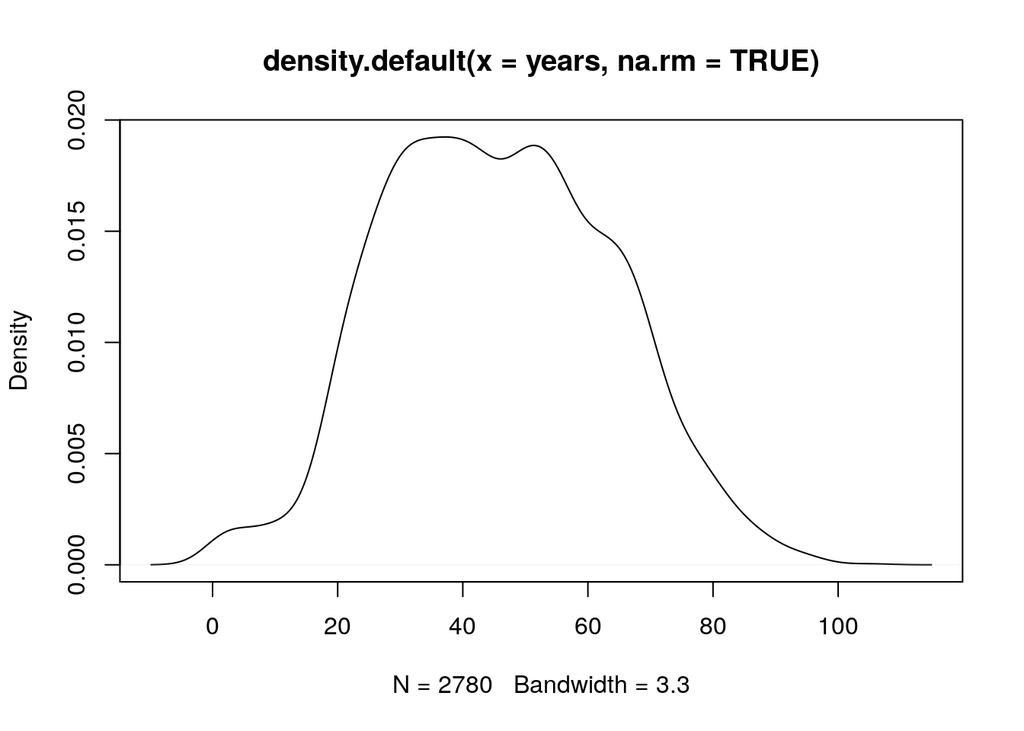

```r
plot(density(years, na.rm=TRUE))
```

## Commentary:

The plot of the `years` distribution shows that we have many fewer COVID cases at very young and at very advanced ages, which make our estimate of the risk of mortality less reliable for those ages.

# Task 10

Removes NA cases.

```r
mydata <- na.omit(data.frame(deceased, years))
```

We can get a rough idea of the relationship between age and death rate by plotting the observed proportion of deaths for each unique age.

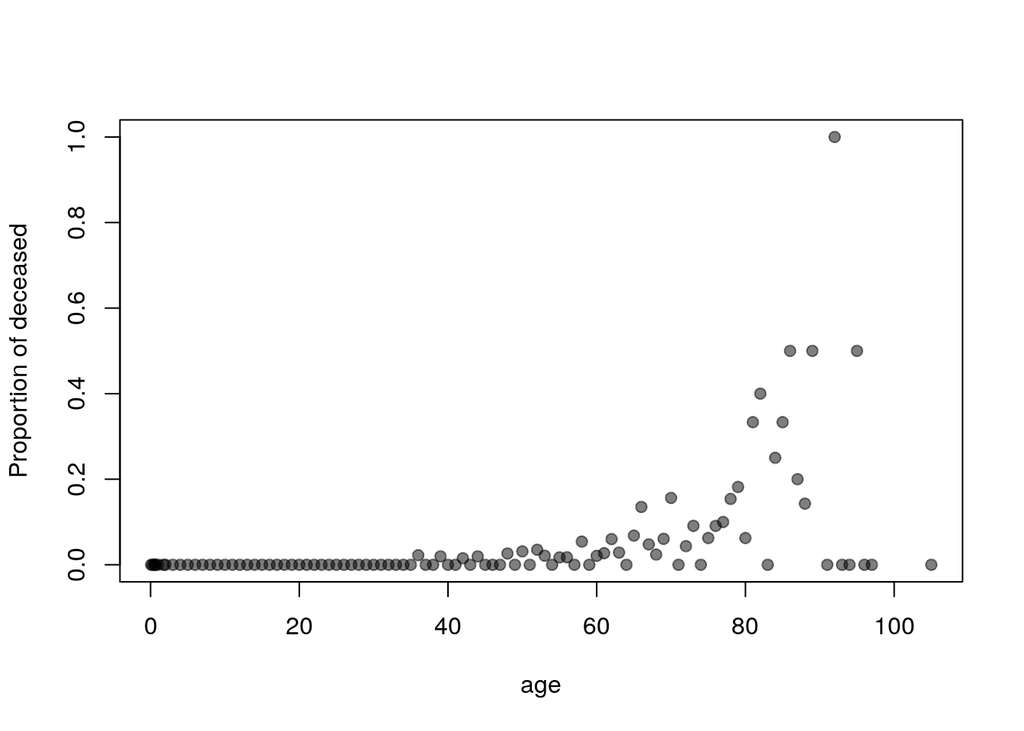

```r
props <- aggregate(mydata$deceased, list(mydata$years), mean)

plot(props, pch=19, col = grey(0, 0.5), xlab = "age", ylab = "Proportion of deceased")
```

## Commentary:

The plot shows evidence of an increase in risk of death with increasing age.

The overall proportion of cases in the new data set (constructed by interested variables) that have died is 0.02410072.

```r
(predProp <- mean(mydata$deceased, na.rm=TRUE))
```

```
## [1] 0.02410072
```

## 10-fold cross-validation

Use 10-fold cross-validation to fit a logistic model to predict the probability of death based on age.

Step 1: Randomly shuffle the data

```r
## Set the seed
set.seed(123)
## Randomly shuffle the data
mydata <- mydata[sample(nrow(mydata)),]
```

Step 2: Create 10 equally size folds & `LogLoss` function

```r
## Step 2.1: Create 10 equally size folds
folds <- cut(seq(1, nrow(mydata)), breaks = 10, labels = FALSE)

## Step 2.2: Create the `LogLoss` function
## Evaluate ('y' should be 1 or 0 [or TRUE/FALSE])
LogLoss <- function(p, y) {
    -mean(y*log(p) + (1 - y)*log(1 - p))
}
```

Step 3: Perform 10-fold cross-validation

```r
out <- numeric(10)
simple <- numeric(10)
### Using for loop to repeat the procedure
for(i in 1:10){
  # Create training set by using the folds not in the fold i
  train <- mydata[folds!=i, ]
  # Create test set by using the fold i
  test <- mydata[folds==i, ]
  ### Use the test and train data
  ### For set i, using the all other 9 sets to fit the logistic model
  fitGLM <- glm(deceased ~ years, data = train, family="binomial")
  ### Predict the the probability of death based on age using the test set (fold) i
  predGLM <- predict(fitGLM, data.frame(x=test["years"]), type="response")
  ### Then, calculate the log-loss value
  # For the model
  out[i] <- LogLoss(predGLM, test$deceased)
  # For the simple overall proportion
  predProp <- mean(train$deceased, na.rm=TRUE)
  simple[i] <- LogLoss(predProp, test$deceased)
}
```

# Task 11

## Evaluation:

Step 4: Average over 10 estimates of log-loss values

```r
mean(out) # logistic model
```

```
## [1] 0.09187556
```

```r
mean(simple) # simple overall
```

```
## [1] 0.1141597
```

## Commentary:

The log-loss value for the logistic model is lower than the log-loss for a model that only assumes a constant risk of death for all ages, indicating that the logistic model is capturing some of the patterns in the data (i.e., there is some evidence that the risk of death increases with age).

Visualization:

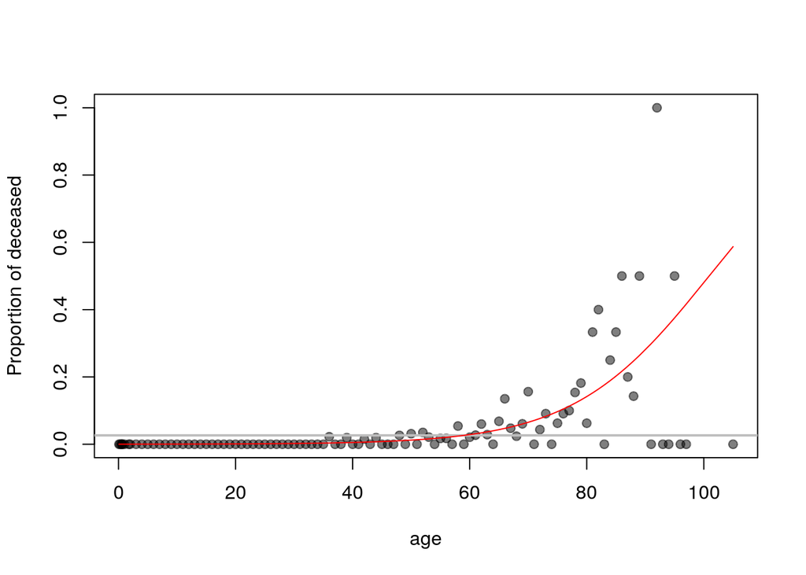

```r
plot(props, pch=19, col = grey(0, 0.5), xlab = "age", ylab = "Proportion of deceased")
fit <- glm(deceased ~ years, data = mydata, family="binomial")
pred <- predict(fit, data.frame(x=mydata["years"]), type="response")
abline(h=predProp, col="grey", lwd = 2)
o <- order(mydata$years)
lines(mydata$years[o], pred[o], col="red")
```

## Commentary:

# Conclusion

- The data consist of $99,975$ individual COVID-19 cases in a CSV file. We looked at the relationship between patient age and the probability of death and found some evidence that risk of death increases with age.
- We evaluated the model on the test set (by using 10-fold cross-validation) and compared its performance to a simple overall proportion. The predictions based on our model seem to perform better (smaller log loss) compared to the one using the simple overall proportion. Our model captures most of the data, but some observations around age $90$ to $105$ are left behind.
- One reason for caution is that we have much less data for people at advanced ages and we lose about one third of deceased cases when created `years` variable for our analysis. In that case,our estimate of the risk of mortality is not very reliable.

An additional problem is that the data contain “censored” observations. There may be patients in the data set who did not survive, but were still alive when the data set was recorded.

# Appendix: Shell Command

```bash
## Generate HTML
Rscript -e 'library(rmarkdown); render("lab03-xfan994.Rmd")'
## Generate PDF
Rscript -e 'library(rmarkdown); render("lab03-xfan994.Rmd", "pdf_document")'
## Generate gzipped tar ball
tar cvfz ./lab03-xfan994.tar.gz .
```